# POLS 1600: Interpreting Regression Models with Mutliple Predictors

Updated

# Overview

Last week we developed some intuitions about and experience with one of the workhorse tools of this course – the lineaer model.

The key takeaways from this are:

- Linear models provide linear estimates to a conditional mean function by minimizing the sum of squared errors
- When the conditional mean function is linear, linear models give us conditional means
  - This is what we saw with our simple regression of deaths from civil wars on type of peacekeeping.
- When the conditional mean function is not linear, a linear model provides the “best” linear estimate of that function.

This class we’ll develop some tools and intuitions for interpreting models with **multiple predictors.**

A model with one outcome and one predictor is called a bivariate model or a bivariate regression.

A model with multiple predictors (and one outcome) is called a multiple regression model.

Sometimes people call these models multivariate regressions. This is technically incorrect, but fairly common. Technically, multivariate regression involves multiple outcomes (a system of equations/regression models), but I wouldn’t “well actually” someone who uses the term multivariate regression – just keep your smug satisfication to yourself.

The key takeaways for this week are:

- **A multiple regression is just an equation that says our outcome is a (linear) function of your predictors**
- **We interpret the coefficients on our predictors as slopes: A unit change in $x$ is associated with a $\beta_x$ change in $y$, all else equal.**
  - Sometimes you’ll here these $\beta$s described as marginal effects or partial derivatives. The more mathematical interpretation of $\beta$ as partial derivative can be useful, particularly when we have an model with an interaction between two variables. As you’ll see in the notes below the marginal effect of x on y, then depends on the value z takes (and vice versa)
- **The phrase “all else equal” is one of those terms that packs in a lot. We’ll start to develop our understanding of what it means substantively and technically to “control for” variables in a regression**
  - When people include this phrase typically it’s to denote the fact that a coefficient is from a multiple regression model in which we have controlled for other variables beside x
    - Conceputally, it means that $\beta$ tells us something about how y will vary with a change in x, once we have removed the variation in both x and y associated with other variables in our model $z$
    - Mathematically, it’s what happens when we take a partial derivative of y with repect to x, holding other variables fixed or constant.
    - So sometimes you’ll hear people say the marginal effect of x on y controlling for z is $\beta$ or the marginal effect of x on y is $\beta$ ceterus paribus (with other conditions remaining the same.) because everything sounds better in Latin. Again don’t be blinded by jargon
- **To make predictions from our linear model, we simply plug in values for the variables in our equation.**
- **Often it’s useful to think about different types of models in terms of how we would interpret their predictions graphically**

## Next week

Next week, we’ll get into some more specifics about fitting models with many predictors and how we should interpret and evaluate predictions from those models.

# Mutliple Regression

- We’ll spend the bulk of this course we working with linear models
  - Relatively simple to estimate and interpret
  - Some nice statistical properties
  - Foundation for understanding more complicated models

## Some Definitions

- $Y$ some (for today) continuous outcome
- $X$ a continuous predictor
- $Z$ another continuous predictor
- $D$ a dichotomous predictor
- $G$ a categorical predictor with more than two levels
- $\beta_i$ the coefficient for predictor $i$
- $u_i$ the residual for $i$ (difference between observed and predicted)

## Some Data

Let’s load some data from the 2016 NES

```r
load(url("https://raw.github.com/PTesta/POLS_1600/master/nes.rda"))
# Look at data
dim(nes)
```

```
[1] 1200   14
```

```r
head(nes)
```

```
  caseid    state age gender educ faminc pid7 ideo5 pol_interest church_atd bornagain01 ft_trump
1    745  Alabama  19      2    3     97    5     3            1          2           0        3
2   1115  Alabama  46      1    3      3    1     1            3          6           0        0
3    258  Alabama  59      2    2      6    2     3            2          1           1       22
4    126  Alabama  55      2    4      6    1     2            3          5           0        1
5    414  Alabama  66      1    3      8    7     4            3          3           1      100
6    523  Alabama  61      1    2     97    1     2            3          6           1        0
  ft_hrc vote_choice
1     19       Other
2     36         HRC
3      2        <NA>
4     80         HRC
5      3        <NA>
6    100        <NA>
```

Let’s explore how self-reported interest in politics, relates to perceptions of presidentational candidates (Clinton and Trump) in 2016.

Suppose we’re interested in the absolute difference in affect toward candidates – that is, whether someone feels strongly positive about one candidate and strongly negative about another candidate.

For simplicity, let’s compare differences in absolute affect between those who say they follow politics closely, to those who say they don’t.

First, we’ll recode the data:

```r
# Recode
nes$interest01<-ifelse(nes$pol_interest==3,1,0)
nes$tc_diff<-abs(nes$ft_trump-nes$ft_hrc)
```

Next, we’ll formalize our question into a model

$$\text{|FT}_{T} - \text{FT}_H| = \beta_0 + \beta_1 \text{Interest}$$

What do the coefficients tell us?

Why might we expet the coefficient on $\beta_1$ to be positive? Why might we expect it to be negative?

## Candidate Differences modeled by Interest

```r
themodel<-lm(tc_diff~interest01,nes)
themodel
```

```
Call:
lm(formula = tc_diff ~ interest01, data = nes)

Coefficients:
(Intercept)   interest01
       47.8         12.7
```

## Displaying the model

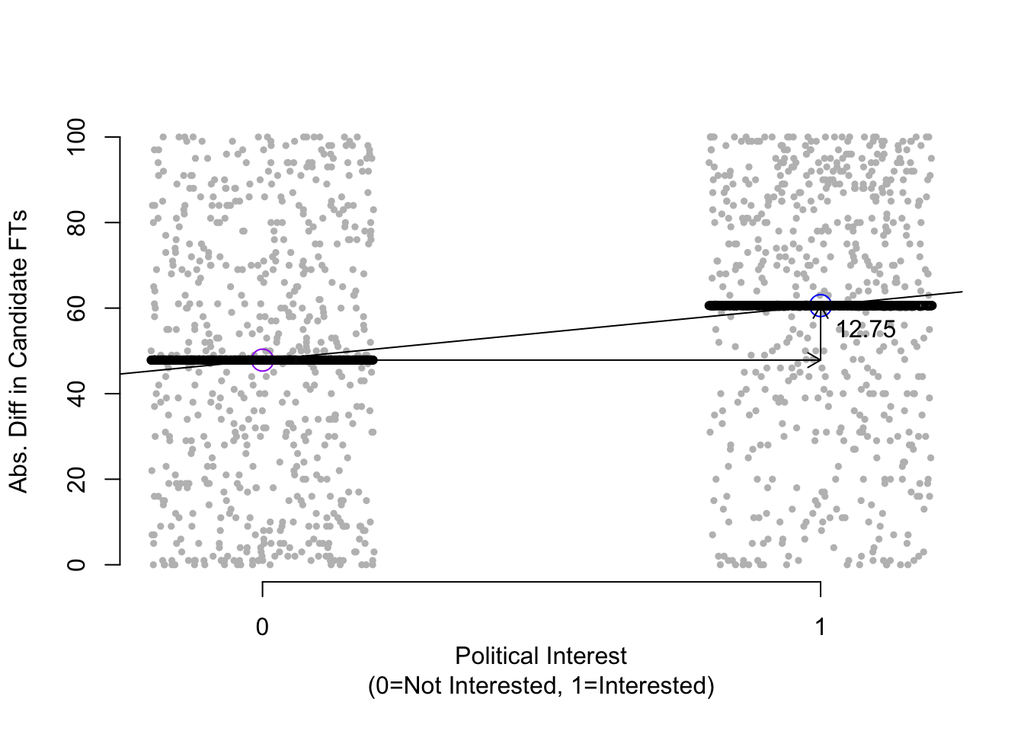

Now let’s think about building models more generally, starting with the simplest possible model

## The Empty Model

$$Y = \beta_0 + u_i$$

What’s your best prediction for some outcome, knowing nothing else?

```r
lm0<-lm(tc_diff~1,nes)
coef(lm0)
```

[output not shown]

```r
mean(nes$tc_diff,na.rm=T)
```

[output not shown]

```r
ssr0 <- sum(resid(lm0)^2)
ssr0
```

```
[1] 1216762
```

A prediction of the unconditional mean of the outcome, will minimize the sum of squared errors.

Now let’s add some information, like whether people say they’re interested in politics

## A model with a single dichotomous predictor

$$Y= \beta_0 + \beta_1D_i + u_i$$

This is just the model from above telling us how feelings toward candidates differ by levels of political interest?

```r
lm1<-lm(tc_diff~interest01,nes)
coef(lm1)
```

```
(Intercept)  interest01
      47.84       12.75
```

```r
mean(tc_diff~interest01,data=nes,na.rm=T)
```

```
    0     1
47.84 60.59
```

```r
diff(mean(tc_diff~interest01,data=nes,na.rm=T))
```

```
    1
12.75
```

```r
ssr1 <- sum(resid(lm1)^2)
ssr1 < ssr0
```

```
[1] TRUE
```

Note the sum of squared residuals has decreased from lm0 to lm1. Adding predictors increases the portion of total variance explained by our model (and decreases the portion unexplained)

Let’s review how we would handle categorical predictor, say modeling absolute differences in feelings toward the candidate by each level of political interests

## A model with a categorical predictor

$$Y_i= \beta_0 + \beta_1 G_i + u_i$$

```r
table(nes$pol_interest)
```

```
  0   1   2   3
 78 178 348 568
```

```r
lm2<-lm(tc_diff~factor(pol_interest),nes)
head(model.frame(lm2))
```

```
  tc_diff factor(pol_interest)
1      16                    1
2      36                    3
3      20                    2
4      79                    3
5      97                    3
6     100                    3
```

```r
head(model.matrix(lm2))
```

```
  (Intercept) factor(pol_interest)1 factor(pol_interest)2 factor(pol_interest)3
1           1                     1                     0                     0
2           1                     0                     0                     1
3           1                     0                     1                     0
4           1                     0                     0                     1
5           1                     0                     0                     1
6           1                     0                     0                     1
```

```r
t(t(coef(lm2)))
```

```
                        [,1]
(Intercept)           46.104
factor(pol_interest)1  1.727
factor(pol_interest)2  2.136
factor(pol_interest)3 14.488
```

```r
mu_0<-with(nes,mean(tc_diff[pol_interest==0],na.rm=T))
mu_1<-with(nes,mean(tc_diff[pol_interest==1],na.rm=T))
mu_2<-with(nes,mean(tc_diff[pol_interest==2],na.rm=T))
mu_3<-with(nes,mean(tc_diff[pol_interest==3],na.rm=T))
```

```r
coef(lm2)[1]
```

```
(Intercept)
       46.1
```

```r
mu_0
```

```
[1] 46.1
```

```r
coef(lm2)[2]
```

```
factor(pol_interest)1
                1.727
```

```r
mu_1-mu_0
```

```
[1] 1.727
```

```r
coef(lm2)[3]
```

```
factor(pol_interest)2
                2.136
```

```r
mu_2-mu_0
```

```
[1] 2.136
```

```r
coef(lm2)[4]
```

```
factor(pol_interest)3
                14.49
```

```r
mu_3-mu_0
```

```
[1] 14.49
```

What if we hadn’t used the factor function?

Then R would treat the pol_interest variable as a numeric variable and we’d have:

## A model with a single continous predictor

$$Y_i= \beta_0 + \beta_1X_i + u_i$$

```r
lm3<-lm(tc_diff~pol_interest,nes)
coef(lm3)
```

```
 (Intercept) pol_interest
      40.799        6.012
```

We interpret the coefficient on $pol\_interest$ like the slope of a line (i.e. a 1 unite change in political interest is associated with 6.01 unit increase in perceived candidate differences)

- What provides a better fit?

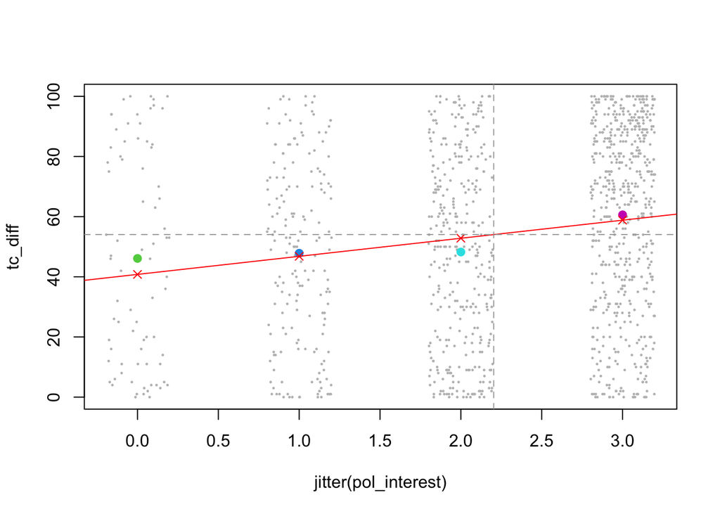

```
[1] TRUE
```

```
[1] -11371
```

```
[1] 0.04092
```

```
[1] 0.04092
```

```
[1] 0.03117
```

```
[1] 0.03117
```

Let’s see what happens when we add a continuous predictor to our model, like age

## A model with both a dichtomous and continous predictor

$$Y_i= \beta_0 + \beta_1D_i+\beta_2X_i + u_i$$

```r
lm4<-lm(tc_diff~interest01+age,nes)
lm4
```

```
Call:
lm(formula = tc_diff ~ interest01 + age, data = nes)

Coefficients:
(Intercept)   interest01          age
     32.176        9.774        0.353
```

What have we done?

Well one way to think about this model, is that we have a belief that perceptions about candidates are related to both people’s levels of political interest and their age.

We also think that interest and age may be related.

So by fitting a model with both predictors, we attempt to control for the variance explained by one variable when trying to identify the variatio explained by the other variable.

That is, once we know all there is to know about age’s relationship to interest and age’s relationship to perceptions of candidate differece, does political interest explain any additional variation in candidate perceptions (and vice versa, once we know the relationship between interest and perceptions, does age explain any additional variation)

We can do this manually, by estimating a series of bivariate regressions of affect on age and interest on age, and then regressing the residuals from the first model on the residuals from the second:

```r
# 1. Regress affect on age
lm4_affect_on_age <- lm(tc_diff~age, data=lm4$model)

# 2. Save portion of affect not explained by age
tc_diff_res <- lm4_affect_on_age$residuals

# 3. Check: Are residuals associated with age
round(cor(tc_diff_res, lm4_affect_on_age$model$age),5)
```

```
[1] 0
```

```r
# 4. Regress interest on age
lm4_interest_on_age <- lm(interest01 ~ age, data = lm4$model)
interest01_res <- lm4_interest_on_age$res

# 5. Check: Are residuals associated with age
round(cor(interest01_res, lm4_interest_on_age$model$age),5)
```

```
[1] 0
```

```r
# 6. Regress remaining variation in affect not explained by age
#    on variation in interest not explained by age
lm4_res <- lm(tc_diff_res ~ interest01_res)

# 7. Same as coefficient on interest01 from lm4
coef(lm4_res)[2]
```

```
interest01_res
         9.774
```

```r
coef(lm4)[2]
```

```
interest01
     9.774
```

In terms of our interpetring our model graphically, we can think of the dichotomous predictor as shifting the intercept of a line whose slope is defined by the coefficient on age.

```
  interest01 age
1          0  19
2          1  19
3          0  20
4          1  20
5          0  21
6          1  21
```

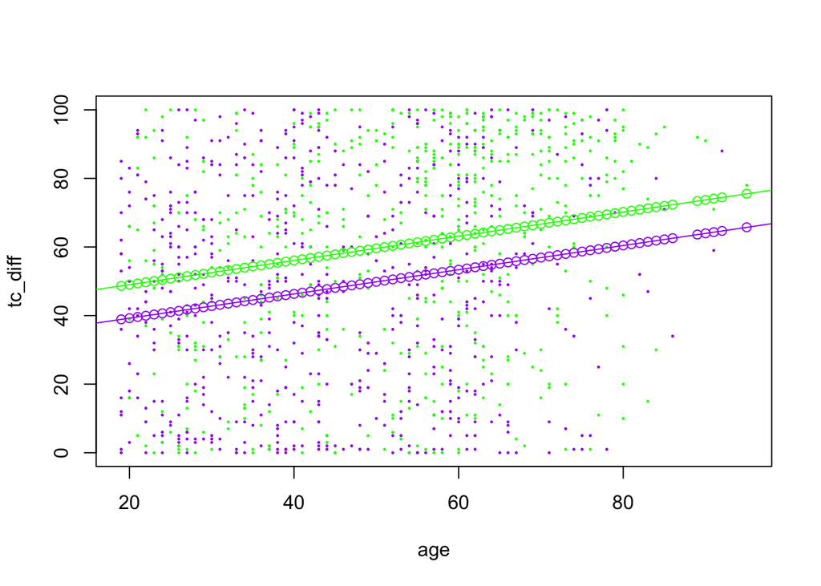

## A model with an interaction between D and X

Suppose we thought the relationship between age and perceptions depended on levels of interest. We could represent this model with an interaction:

$$Y_i= \beta_0 +\beta_1D_i + \beta_2X_i + \beta_3D_i\times X_i$$

- $\beta_1$ shifts the intercept
  - From $\beta_0$ (D=0) to $\beta_0+\beta_1$ (D=1)
- $\beta_3$ changes the slope
  - From $\beta_2$ (D=0) to $\beta_2+\beta_3$ (D=1)

Let’s fit that model

```r
# * is a short cut for writing the full interaction
lm5<-lm(tc_diff~interest01*age,nes)
lm5
```

```
Call:
lm(formula = tc_diff ~ interest01 * age, data = nes)

Coefficients:
   (Intercept)      interest01             age  interest01:age
        39.763          -6.704           0.182           0.340
```

And plot the results to see if the relationship between age and perceptions differs conditional on interest?

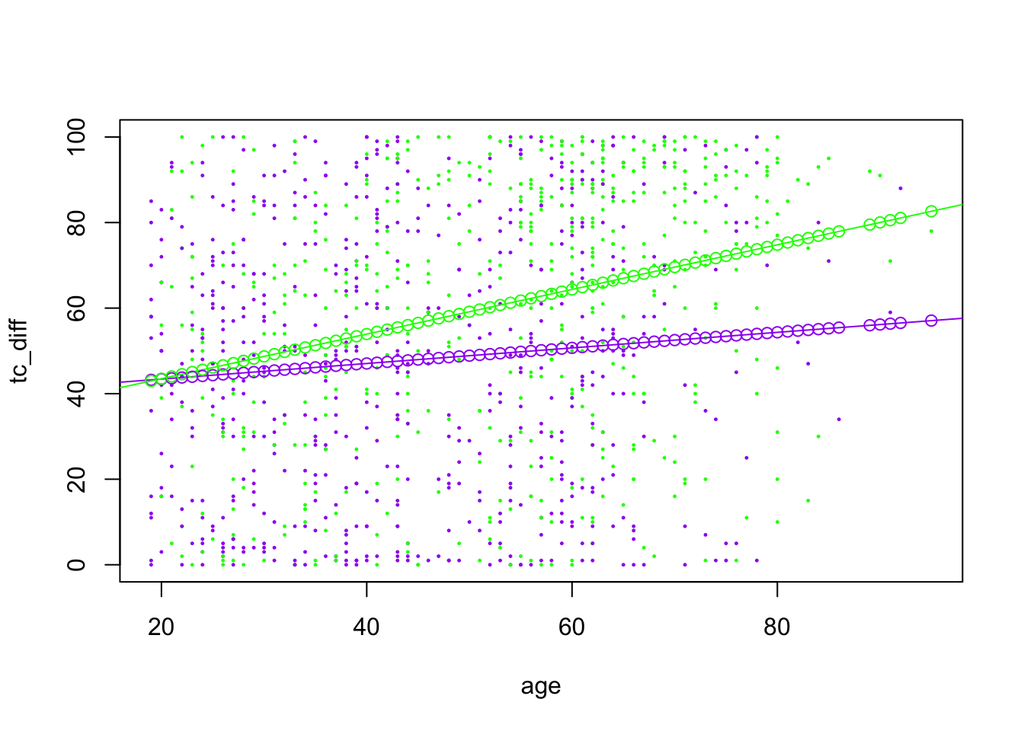

We could get the same two lines, by fitting separate models on just the interested and uninterested:

```r
# Subsetting with an index
lm5_uninterested <- lm(tc_diff ~ age, data = nes[nes$interest01 == 0,])

coef(lm5_uninterested)["age"]
```

```
   age
0.1823
```

```r
# Same as
coef(lm5)["age"]
```

```
   age
0.1823
```

```r
# Subsetting with an argument
lm5_interested <- lm(tc_diff ~ age, data = nes, subset = interest01 == 1)

coef(lm5_interested)["age"]
```

```
   age
0.5219
```

```r
# Same as
coef(lm5)["age"] + coef(lm5)["interest01:age"]
```

```
   age
0.5219
```

## A model with two continuous predictors

$$Y_i\sim 1 + X_i + Z_i$$

- Essentially adding another dimension to our model

```r
nes$income<-ifelse(nes$faminc>16,NA,nes$faminc)
lm6<-lm(tc_diff~age+income,nes)
lm6
```

```
Call:
lm(formula = tc_diff ~ age + income, data = nes)

Coefficients:
(Intercept)          age       income
     33.199        0.400        0.157
```

Which we can visualize:

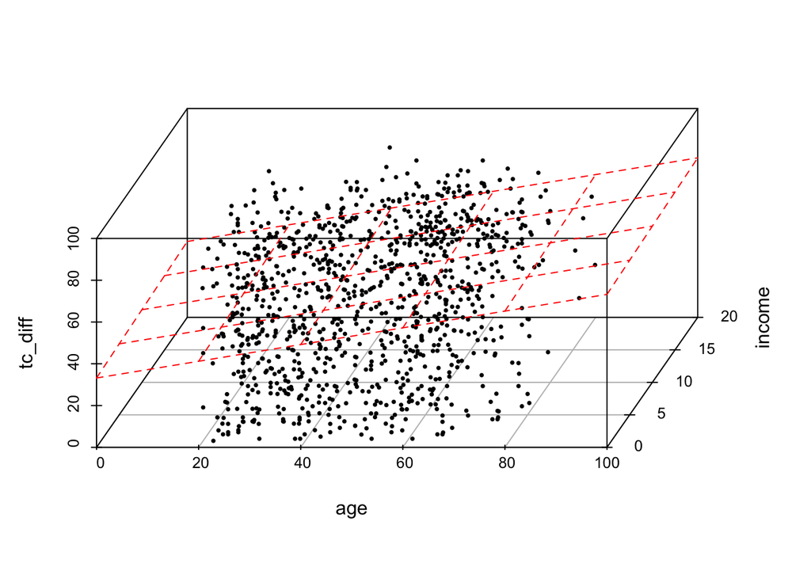

## Multiplicative Interactions with a continuous moderator

$$Y= \beta_0 + \beta_1X + \beta_2 +\beta_3X\times Z$$

- The marginal effect of X on Y, now depends on the value of Z at which you evaluate the relationship

$$\frac{\partial Y}{\partial X}=\beta_1+\beta_3Z$$

Easier to show this with some simulated data:

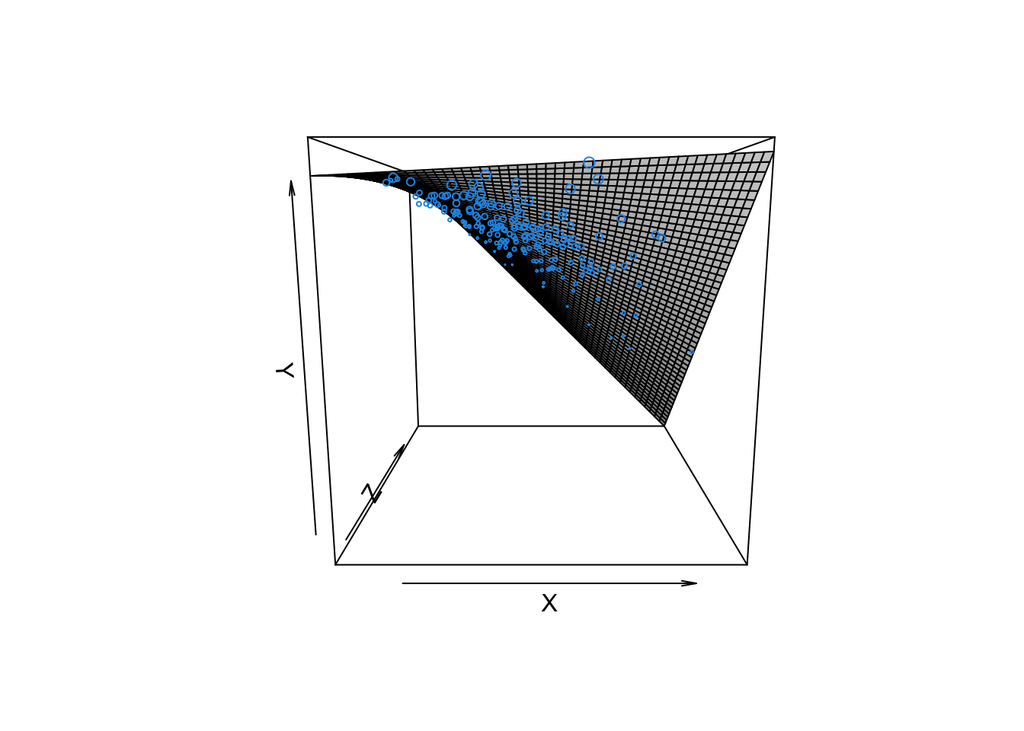

Another Perspective

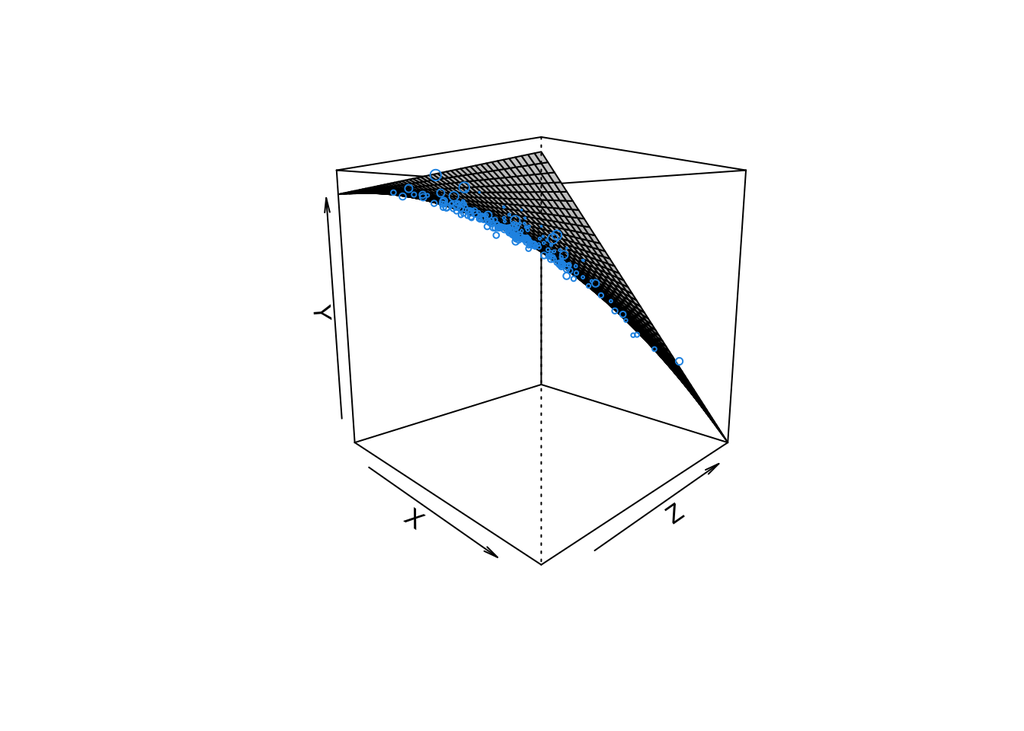

# ICYI Some of the Math Behind OLS Regression

This isn’t really central to our task in course (hence the ICYI), but is useful if you plan to continue on in future courses. So below is a brief discussion of how to estimate OLS regression with multiple predictors, it requires a little bit of linear algebra.

Last week we saw that in a bivariate (two variable) world, OLS chose coefficients to minimize the sum of squared errors

$$\textrm{Find }\widehat{\beta_0},\,\widehat{\beta_1} \text{ argmin }_{\beta_0, \beta_1} \sum (Y-(\beta_0+\beta_1X))^2$$

Giving us:

$$\beta_0 = \bar{Y} - \beta_1 \bar{X_{1}}$$
And
$$\beta_1 = \frac{\sum (Y_i -\bar{Y})(X_{1,i}-\bar{X_1})}{\sum (\bar{X_1}-X_{1,i})^2}=\frac{Cov{[X,Y]}}{Var[X]}$$

## OLS with Multiple Predicors

That’s great, but what if we want to predict $Y$ with more than just one $X$, like:

$$Y=\beta_0+\beta_1X_1+\beta_2X_2 + \dots +\beta_kX_k +\epsilon$$

The criterion remains the same–we want to minizime the sum of the squared residuals $\sum \epsilon^2$, but we’ll need to use matix algebra to simplify the math.

## OLS in matrix form

Spefically, we can write:

$$Y=\beta_0+\beta_1X_1+\beta_2X_2 + \dots +\beta_kX_k +\epsilon$$

As
$$Y= \begin{bmatrix}
Y_1 \\
Y_2 \\
\vdots \\
Y_n
\end{bmatrix}$$
$$X=
\begin{bmatrix}
1 & X_{1,1}&\dots & X_{1,k}\\
1 & X_{2,1}&\dots & X_{2,k}\\
\vdots&\vdots& & \vdots \\
1 & X_{n,1}&\dots & X_{n,k}\\
\end{bmatrix}$$
$$\beta=
\begin{bmatrix}
\beta_0\\
\beta_1\\
\vdots \\
\beta_k\\
\end{bmatrix}$$

$$\epsilon=
\begin{bmatrix}
\epsilon_1\\
\epsilon_2\\
\vdots\\
\epsilon_n
\end{bmatrix}$$

$$Y=X\beta+\epsilon$$

## Residuals

Our residual (error), is simply

$$Y=X\beta+\epsilon$$

$$\epsilon=Y-X\beta$$

Note that our $\epsilon$ is a $n\times$ column vector:

$$\epsilon=
\begin{bmatrix}
\epsilon_1\\
\epsilon_2\\
\vdots\\
\epsilon_n
\end{bmatrix}$$
And it’s transpose, $\epsilon^\prime$ is a $1\times n$ row vector

$$\epsilon^\prime=[\epsilon_1,\epsilon_2,\dots,\epsilon_n]$$

## Minimizing the sum of Squared Residuals with Matrix Algebra

Taking the inner product of a vector ($\epsilon^\prime\epsilon$) is the equivalent of $\sum \epsilon^2$

So our task becomes:

$$\textrm{Find }\widehat{\beta} \text{ argmin }_{\widehat{\beta}} \sum \epsilon^2=\epsilon^\prime\epsilon=(Y-X\widehat{\beta})^\prime(Y-X\widehat{\beta})$$

Distributing the transpose and expanding that last expression we get:

$$\begin{align}
\epsilon^\prime\epsilon &=(Y-X\widehat{\beta})^\prime(Y-X\widehat{\beta})\\
&=Y^\prime Y-\widehat{\beta}^\prime X^\prime Y-Y^\prime X \widehat{\beta} +\widehat{\beta}^\prime X^\prime X\widehat{\beta}
\end{align}$$

At this point, it’s probably useful to have some toy numbers to illustrate what’s going on.

## Example data with 5 observations and two predictors

```r
y=c(1,2,4,6,10)
x1=c(-3,3,2,4,8)
x2=c(1,5,3,5,2)
X<-cbind(1,x1,x2)
X
```

```
       x1 x2
[1,] 1 -3  1
[2,] 1  3  5
[3,] 1  2  3
[4,] 1  4  5
[5,] 1  8  2
```

## Claim: $-\widehat{\beta}^\prime X^\prime Y$=$-Y^\prime X \widehat{\beta}$

Both $X^\prime Y$ and $Y^\prime X$ yield vectors with the same values

```r
# t() is R's transpose function (switch index of rows and columns)
t(X)%*%y
```

```
   [,1]
     23
x1  115
x2   73
```

```r
t(y)%*%X
```

```
         x1 x2
[1,] 23 115 73
```

Which when pre multiplied by some $\widehat{\beta}^\prime$ (e.g. $\widehat{\beta}^\prime X^\prime Y$) or post-multipled by $\widehat{\beta}$ (ie.. $-Y^\prime X \widehat{\beta}$), give the same value.

```r
# Pick a random vector for illustration
beta_ex<-1:3
t(beta_ex)%*%t(X)%*%y
```

```
     [,1]
[1,]  472
```

```r
t(y)%*%X%*%beta_ex
```

```
     [,1]
[1,]  472
```

## Minimizing the sum of Squared Residuals with Matrix Algebra

So now we can combine the second and third terms:

$$\begin{align}
\epsilon^\prime\epsilon &=(Y-X\widehat{\beta})^\prime(Y-X\widehat{\beta})\\
&=Y^\prime Y-\widehat{\beta}^\prime X^\prime Y-Y^\prime X \widehat{\beta} +\widehat{\beta}^\prime X^\prime X\widehat{\beta}\\
&=Y^\prime Y-2\widehat{\beta}^\prime X^\prime Y+\widehat{\beta}^\prime X^\prime X\widehat{\beta}
\end{align}$$

## Claim: $X^{\prime}X$ is symmetric

A symmetric matrix is one where

$$A^\prime=A$$

Only square matrices can be symmetric

Let’s look at our toy example

```r
XtX<-t(X)%*%X
XtX
```

```
       x1 x2
    5  14 16
x1 14 102 54
x2 16  54 64
```

```r
t(XtX)
```

```
       x1 x2
    5  14 16
x1 14 102 54
x2 16  54 64
```

Let’s look at our toy example

```r
XtX==t(XtX)
```

```
          x1   x2
   TRUE TRUE TRUE
x1 TRUE TRUE TRUE
x2 TRUE TRUE TRUE
```

## First Order Conditions

Ok, so now we just need to take the derivative of $\epsilon^{\prime}\epsilon$ with respect to $\widehat{\beta}$ and set it 0

$$\frac{\partial[\epsilon^{\prime}\epsilon]}{\partial\widehat{\beta}}=-2X^\prime Y+2X^{\prime}X\widehat{\beta}=0$$

## Matrix Differentiation

For $k\times1$ vectors $a$ and $b$:

$$\frac{\partial[a^\prime b]}{\partial b}=\frac{\partial[b^\prime a]}{\partial b}=a$$

When $A$ is a symmetric matrix

$$\frac{\partial[a^\prime b]}{\partial b}=2Ab=2b^\prime A$$

$$\frac{\partial[2\widehat{\beta} X^{\prime}Y ]}{\partial\widehat{\beta}}=2X^{\prime}Y$$

And

$$\frac{\partial[2\widehat{\beta} X^{\prime}X\widehat{\beta} ]}{\partial\widehat{\beta}}= \frac{\partial[\widehat{\beta}^\prime A \widehat{\beta}]}{\partial \widehat{\beta}}= 2X^{\prime}X\widehat{\beta}$$

## First Order Conditions

Ok, so now we just need to take the derivative of $\epsilon^{\prime}\epsilon$ with respect to $\widehat{\beta}$ and set it 0

$$\frac{\partial[\epsilon^{\prime}\epsilon]}{\partial \widehat{\beta}}=-2X^\prime Y+2X^{\prime}X\widehat{\beta}=0$$

$$\begin{align}
-2X^{\prime}Y+2X^{\prime}X\widehat{\beta}&=0\\
2X^{\prime}X\widehat{\beta}&= 2X^{\prime}Y\\
X^{\prime}X\widehat{\beta}&= X^\prime Y\\
\left[X^{\prime}X\right]^{-1}X^{\prime}X\widehat{\beta} &= \left[X^{\prime}X\right]^{-1}X^{\prime}Y\\
I\widehat{\beta}&= \left[X^{\prime}X\right]^{-1} X^{\prime}Y\\
\widehat{\beta}&= \left[X^{\prime}X\right]^{-1} X^{\prime}Y
\end{align}$$

## Second Order Conditions

If we were to take the derviative of $\epsilon^{\prime}\epsilon$ a second time we’d get $2X^{\prime}X$ , which provided x has full rank is a positive definite matrix meaning $\widehat{\beta}$ provide a minium for $\epsilon^{\prime}\epsilon$

## Simple example

```r
# Math
solve(XtX)%*%t(X)%*%y
```

```
      [,1]
    4.2959
x1  0.9082
x2 -0.6997
```

```r
# R
lm1<-lm(y~x1+x2,data.frame(y,x1,x2))
lm1
```

```
Call:
lm(formula = y ~ x1 + x2, data = data.frame(y, x1, x2))

Coefficients:
(Intercept)           x1           x2
      4.296        0.908       -0.700
```

## Properties of OLS

Recall

$$Y=X\widehat{\beta}+\epsilon$$

Plug in to (normal form) equqtions

$$\begin{align}
X^{\prime}X\widehat{\beta}=X^{\prime}Y\\
X^{\prime}X\widehat{\beta}=X^{\prime}[X\widehat{\beta}+\epsilon]\\
X^{\prime}X\widehat{\beta}=X^{\prime}X\widehat{\beta}+X^{\prime}\epsilon\\
X^{\prime}\epsilon=0
\end{align}$$

This is simply a result of our fitting procedure. That is it will always be true for the model we fit to some data

```r
e=resid(lm1)
```

From $X^{\prime}\epsilon=0$ a number of properties follow

1. Observed values of $X$ are uncorrelated with $\epsilon$

   ```r
   round(cor(cbind(x1,x2,e)),2)
   ```

   ```
        x1   x2 e
   x1 1.00 0.32 0
   x2 0.32 1.00 0
   e  0.00 0.00 1
   ```

2. The $\sum \epsilon$ and sample mean of $\epsilon$ are 0

```r
sum(e);mean(e)
```

```
[1] 2.082e-17
```

```
[1] 4.199e-18
```

3. The models predictions include the conditional means of $Y$ and $X$

   ```r
   predict(lm1,newdat=data.frame(x1=mean(x1),x2=mean(x2)))
   ```

   ```
     1
   4.6
   ```

   ```r
   mean(y)
   ```

   ```
   [1] 4.6
   ```

4. The models prediction $\widehat{Y}$ are uncorrelated with $\epsilon$

   ```r
   round(cor(cbind(yhat=fitted(lm1),e)),2)
   ```

   ```
        yhat e
   yhat    1 0
   e       0 1
   ```

## What are the assumptions necessary to justify OLS?

Read 10 textbooks, get 10 different answers about assumptions “necessary” for OLS

- Nature of the data
- About the structure of the relationship
- About the distribution of the errors

“Necessary” typically means something like necessary for OLS to be unbiased or provide correct standard errors.

Here’s an example of the Assumtions for OLS from a PoliSci text (Lewis-Beck)

1. No specification error
- The relationship between Y and X is linear
- We’ve got the correct model
2. No measurement error
- Measurement error in Y vs in X have different implications
3. A well-behaved error term, $\epsilon$
- $E[\epsilon]=0$ (zero mean)
- $E[\epsilon^2]=\sigma^2$ (homoscedasticity)
- $E[\epsilon_i\epsilon_j]=0 \forall i \neq j$ (no correlation in errors)
- $\epsilon \sim N(0,\sigma^2)$ (Normality)

Properties of OLS under these assumptions

- The estimated coefficients from OLS are the best linear unbiased estimator (BLUE) of the population parameters, where best means lowest variance (among linear unbiased estimators)

## An Econometric Statement

1. Linear in parameters and correct specification
2. X has full rank
3. Explanatory variables are exogenous
4. Errors are independent and identically distributed
5. In the population, errors are normally distributed

## Linear in parameteres and correct spefication

$$y=X\beta+u$$

The relationship between X and Y is linear in parameters (i.e. a change in X is associated with same change in Y)

Violations: non-linear relationship, omitted variables

## X has full rank

Essentially no variable can be expressed as a linear combination of some other variables (Why we had to drop one level of the treatment when estimating the ATE for the Findley data)

Violations: Including indicators for both male and female in a model with an intercept

## Explanatory variables are exogenous

$$E[\epsilon|X]=0$$

- X is fixed in repeated sampling and all estimates are conditional on X, or X is random and independent of population residuals
- Violations: omitted variables, measurement error and simultaneity

## Errors are independent and identically distributed

$$\epsilon \sim iid(0,\sigma^2)$$

- What it’s saying:
  - $E[\epsilon]=0$ in the population
  - $E[\epsilon\epsilon^\prime]=\Omega=\sigma^2I$ in the population
- $Var[\epsilon]=\sigma^2$ for all $i$
  - $Cov[\epsilon_i,\epsilon_j]=0$ for all $i$
  - Violations: omitted variables, heteroscedasticity, auto-correlation (multiple observations of the same unit over time, spatial analysis)

# ICYI Bias and Variance of OLS

## OLS is unbiased estimator of $\beta$

$$\begin{align}
\widehat{\beta} &= \left[X^{\prime}X\right]^{-1}X^{\prime}Y\\
\widehat{\beta} &= \left[X^{\prime}X\right]^{-1}X^{\prime}(X\beta+\epsilon)\\
\widehat{\beta} &= \left[X^{\prime}X\right]^{-1}X^{\prime}X\beta+\left[X^{\prime}X\right]^{-1}X^{\prime}\epsilon\\
\widehat{\beta} &= \beta+\left[X^{\prime}X\right]^{-1}X^{\prime}\epsilon
\end{align}$$

If $X$ is fixed, then $E[\epsilon]=0$ and

$$\begin{align}
E[\widehat{\beta}]&=E[\beta]+E[\left[X^{\prime}X\right]^{-1}X^{\prime}\epsilon]\\
E[\widehat{\beta}]&=E[\beta]+\left[X^{\prime}X\right]^{-1}X^{\prime}E[\epsilon]\\
E[\widehat{\beta}]&=E[\beta]
\end{align}$$

Or $X$ is random but independent of $\epsilon$ so $E[X^{\prime}\epsilon]=0$

$$\begin{align}
E[\widehat{\beta}]&=E[\beta]+E[\left[X^{\prime}X\right]^{-1}X^{\prime}\epsilon]\\
E[\widehat{\beta}]&=E[\beta]+\left[X^{\prime}X\right]^{-1}E[X^{\prime}\epsilon]\\
E[\widehat{\beta}]&=E[\beta]
\end{align}$$

## Variance of OLS estimators

Recall:

$$\widehat{\beta} = \beta+\left[X^{\prime}X\right]^{-1}X^{\prime}\epsilon$$

So the variance of $\widehat{\beta}$

$$E[(\widehat{\beta}-\beta)(\widehat{\beta}-\beta)^\prime]=E[(\left[X^{\prime}X\right]^{-1}X^{\prime}\epsilon)(\left[X^{\prime}X\right]^{-1}X^{\prime}\epsilon)^\prime]$$

Recalling from previous math classes, $(AB)^\prime=B^\prime A^\prime$, we can write

$$E[(\widehat{\beta}-\beta)(\widehat{\beta}-\beta)^\prime]=E[(\left[X^{\prime}X\right]^{-1}X^{\prime}\epsilon)(\left[X^{\prime}X\right]^{-1}X^{\prime}\epsilon)^\prime]$$

As:

$$E[(\widehat{\beta}-\beta)(\widehat{\beta}-\beta)^\prime]=E[(\left[X^{\prime}X\right]^{-1}X^{\prime}\epsilon\epsilon^\prime X\left[X^{\prime}X\right]^{-1}]$$

Assuming a fixed $X$, $E[\epsilon\epsilon^\prime=\sigma^2I]$ and so

$$\begin{align}
E[(\widehat{\beta}-\beta)(\widehat{\beta}-\beta)^\prime]&=\left[X^{\prime}X\right]^{-1}X^{\prime}E[\epsilon\epsilon^\prime ]X\left[X^{\prime}X\right]^{-1}\\
&=\left[X^{\prime}X\right]^{-1}X^{\prime}[\sigma^2 I]X\left[X^{\prime}X\right]^{-1}\\
&=\sigma^2 I\left[X^{\prime}X\right]^{-1}X^{\prime}X\left[X^{\prime}X\right]^{-1}\\
&=\sigma^2 \left[X^{\prime}X\right]^{-1}
\end{align}$$

Where we can estimate $\sigma^2$ from the data

$$\widehat{\sigma}^2=\frac{\epsilon^{\prime}\epsilon}{n-k}$$

## Variance Covariance Matrix of OLS Estimator

$$\begin{align}
Var[\widehat{\beta}]&=E[(\widehat{\beta}-\beta)(\widehat{\beta}-\beta)^\prime]\\
&=
\begin{bmatrix}
Var[\widehat{\beta}_1]& Cov[\widehat{\beta}_1,\widehat{\beta}_2] &\dots&Cov[\widehat{\beta}_1,\widehat{\beta}_k] \\
Cov[\widehat{\beta}_2,\widehat{\beta}_1] &Var[\widehat{\beta}_2] &\dots&Cov[\widehat{\beta}_1,\widehat{\beta}_k] \\
\vdots &\vdots &\vdots &\vdots \\
Cov[\widehat{\beta}_k,\widehat{\beta}_1] &Cov[\widehat{\beta}_k,\widehat{\beta}_2] &\dots&Var[\widehat{\beta}_k,\widehat{\beta}_k]
\end{bmatrix}
\end{align}$$

## Omitted Variable Bias

What happens if we fit:

$$y=X\beta$$

When in truth, the real relationship is

$$y=X\beta + {Z}\gamma+ u$$

Doing the math

$$\widehat{\beta}=(X^{\prime}X)^{-1}X^{\prime}y$$

Plugging the true values of y in

$$\begin{align}
\widehat{\beta}&=(X^{\prime}X)^{-1}X^{\prime}X(\beta +{Z}\gamma+\epsilon)\\
&=(X^{\prime}X)^{-1}X^{\prime}X\beta+ +(X^{\prime}X)^{-1}X^{\prime}{Z}\gamma+(X^{\prime}X)^{-1}X^{\prime}\epsilon)\\
&=\beta +(X^{\prime}X)^{-1}X^{\prime}{Z}\gamma+(X^{\prime}X)^{-1}X^{\prime}\epsilon)
\end{align}$$

Taking expecations, conditional on only $X$
$$\begin{align}
E[\widehat{\beta}|X]&=\beta+(X^{\prime}X)^{-1}X^{\prime}{Z}\gamma\\
&\beta + OVB
\end{align}$$

“Short equals long plus the effect of the ommitted times the regression of the ommitted on the included”

- OVB a violation of conditional independence, estimates are biased, and often we don’t know the direction of that bias.

# Summary

- Multiple regression is a generalization of bivariate regression “to control” for more than one variable.
- Multiple regression tells us how our outcome of interest will change when a predictor changes, holding all the other predictors in the model constant.
- Once you’ve fit a model, to make predictions, simply plug in values for the variables, multiply them by the associated coefficients and evaluate the equation.
- Interaction models allow the relationship (slope) between Y and X to vary based on the value of some other variable Z.
- Omitted variable bias, means are estimated coefficients will be wrong. Generally, we don’t know the direction of this error.